# Klein_FinalExam_12345

Melanie Klein

2024-05-04

Load Packages

```r
library(tidyverse)
library(dplyr)
library(data.table)
library(rvest)
```

1

Use the link https://forecast.weather.gov/MapClick.php?CityName=Washington&state=DC&site=LWX&textField1=38.895&textField2=-77.0373&e=1#.YLPCyflKiUk R code and the Web Scraping methods illustrated in class to collect data on weather for Denver Colorado. The entire table is given below (There may be differences in your table, but structurally, you should get a table very similar to the one shown below. Do not forget to use Chrome and Selector Gadget. Show and use all R code needed for this problem

```r
weatherurl <- read_html("https://forecast.weather.gov/MapClick.php?lat=39.7385&lon=-104.9849")

DayNight <- weatherurl %>%
  html_nodes(".period-name") %>%
  html_text()

Temperatures <- weatherurl %>%
  html_nodes(".temp") %>%
  html_text()

Forecasts <- weatherurl %>%
  html_nodes(".short-desc") %>%
  html_text()

weather_data <- data.frame(
  DayNight = DayNight,
  Temperatures = Temperatures,
  Forecasts = Forecasts,
  DayorNight = DayNight
)

weather_data
```

```
##         DayNight Temperatures                                   Forecasts
## 1 This Afternoon  High: 67 °F                       Slight ChanceT-storms
## 2        Tonight   Low: 46 °F      Slight ChanceT-storms thenMostly Clear
## 3         Sunday  High: 80 °F      Mostly Sunnythen PartlySunny andBreezy
## 4   Sunday Night   Low: 49 °F                      Partly Cloudyand Windy
## 5         Monday  High: 65 °F Windy. SlightChanceShowers thenMostly Sunny
## 6   Monday Night   Low: 43 °F                      Partly Cloudyand Windy
## 7        Tuesday  High: 64 °F              Slight ChanceT-storms andWindy
## 8  Tuesday Night   Low: 38 °F     Partly Cloudyand Breezythen MostlyClear
## 9      Wednesday  High: 63 °F   Sunny thenSlight ChanceT-storms andBreezy
##       DayorNight
## 1 This Afternoon
## 2        Tonight
## 3         Sunday
## 4   Sunday Night
## 5         Monday
## 6   Monday Night
## 7        Tuesday
## 8  Tuesday Night
## 9      Wednesday
```

2

1. Use data.table coding to read in the nyc data as was done in class. Assign the data table to the variable flights3 (The nycdata.csv is found on Canvas in the Data.Table module 3/18/2024)

```r
flights3 <- fread("nycdata.csv")
```

2. Use data.table coding to modify flights3 so that only the column variables origin, dest, and carrier appear.

```r
flights3[, c("origin", "dest", "carrier")]
```

```
##         origin dest carrier
##      1:    JFK  LAX      AA
##      2:    JFK  LAX      AA
##      3:    JFK  LAX      AA
##      4:    LGA  PBI      AA
##      5:    JFK  LAX      AA
##     ---
## 253312:    LGA  IAH      UA
## 253313:    EWR  IAH      UA
## 253314:    LGA  RDU      MQ
## 253315:    LGA  DTW      MQ
## 253316:    LGA  SDF      MQ
```

3. Now use data.table coding that reflects an origin of JFK, a destination of SEA and a carrier of only Delta Airlines DL.

```r
flights3[origin == "JFK" & dest == "SEA" & carrier == "DL"]
```

```
##       year month day dep_delay arr_delay carrier origin dest air_time distance
##    1: 2014     1   1        86        79      DL    JFK  SEA      347     2422
##    2: 2014     1   1        -2        -4      DL    JFK  SEA      347     2422
##    3: 2014     1   2         0        11      DL    JFK  SEA      339     2422
##    4: 2014     1   2        -3         9      DL    JFK  SEA      337     2422
##    5: 2014     1   2        21        19      DL    JFK  SEA      337     2422
##   ---
## 1074: 2014    10  30        -3       -15      DL    JFK  SEA      339     2422
## 1075: 2014    10  31        -6       -26      DL    JFK  SEA      317     2422
## 1076: 2014    10  31        -1        -8      DL    JFK  SEA      338     2422
## 1077: 2014    10  31        -1       -23      DL    JFK  SEA      326     2422
## 1078: 2014    10  31         4       -27      DL    JFK  SEA      318     2422
##       hour
##    1:    9
##    2:   18
##    3:   15
##    4:    7
##    5:   18
##   ---
## 1074:   18
## 1075:    9
## 1076:    6
## 1077:   15
## 1078:   18
```

4. Use data.table coding to remove the variable air_time from the original flights3 data table.

```r
flights3[, !("air_time")]
```

```
##         year month day dep_delay arr_delay carrier origin dest distance hour
##      1: 2014     1   1        14        13      AA    JFK  LAX     2475    9
##      2: 2014     1   1        -3        13      AA    JFK  LAX     2475   11
##      3: 2014     1   1         2         9      AA    JFK  LAX     2475   19
##      4: 2014     1   1        -8       -26      AA    LGA  PBI     1035    7
##      5: 2014     1   1         2         1      AA    JFK  LAX     2475   13
##     ---
## 253312: 2014    10  31         1       -30      UA    LGA  IAH     1416   14
## 253313: 2014    10  31        -5       -14      UA    EWR  IAH     1400    8
## 253314: 2014    10  31        -8        16      MQ    LGA  RDU      431   11
## 253315: 2014    10  31        -4        15      MQ    LGA  DTW      502   11
## 253316: 2014    10  31        -5         1      MQ    LGA  SDF      659    8
```

5. Use and show data.table coding to output the maximum and the minimum values for the variable distance.

```r
max_distance <- max(flights3$distance)
max_distance
```

```
## [1] 4983
```

```r
min_distance <- min(flights3$distance)
min_distance
```

```
## [1] 80
```

6. Use two or three sentences to explain the summary provided below and then use and show data.table coding to produce the table.

The summary calculates the mean distance traveled by each carrier. The following code creates grouped summaries by simultaneously grouping and calculating summaries. It uses the by argument to specify grouping by carrier.

```r
flights3[, .(meandistance = mean(distance)) , by = .(carrier)]
```

```
##     carrier meandistance
##  1:      AA    1384.2184
##  2:      AS    2402.0000
##  3:      B6    1069.1531
##  4:      DL    1261.3273
##  5:      EV     565.3130
##  6:      F9    1604.7653
##  7:      FL     661.9241
##  8:      HA    4983.0000
##  9:      MQ     540.1089
## 10:      VX    2497.4620
## 11:      WN     984.3010
## 12:      UA    1559.5486
## 13:      US     547.9539
## 14:      OO     718.6750
```

3

Provided below is the famous poem “Stopping by the Wood On a Snowy Evening” by Robert Frost. Use the text mining sequence of steps and the R code modeled in class to a) create a tibble, b) find line locations of words, c) produce a word frequency table, and d) and create a bar graph data visualization plot that will also display word frequency trends. Hint(do not forget to process a single spaced body of text; be careful about commas and double quotation marks. Use the examples demonstrated in class.)

Whose woods these are I think I know. His house is in the village though; He will not see me stopping here To watch his woods fill up with snow. My little horse must think it queer To stop without a farmhouse near Between the woods and frozen lake The darkest evening of the year. He gives his harness bells a shake To ask if there is some mistake. The only other sound’s the sweep Of easy wind and downy flake. The woods are lovely, dark and deep, But I have promises to keep, And miles to go before I sleep, And miles to go before I sleep.

```r
library("tm")
library("SnowballC")
library("wordcloud")
library("RColorBrewer")
```

```r
file_path <- "StoppingbytheWoodOnaSnowyEvening.txt"
text <- readLines(file_path)
docs <- Corpus(VectorSource(text))
inspect(docs)
```

```
## <<SimpleCorpus>>
## Metadata:  corpus specific: 1, document level (indexed): 0
## Content:  documents: 16
##
##  [1] Whose woods these are I think I know. His house is in the village though;
##  [3] He will not see me stopping here      To watch his woods fill up with snow.
##  [5] My little horse must think it queer   To stop without a farmhouse near
##  [7] Between the woods and frozen lake     The darkest evening of the year.
##  [9] He gives his harness bells a shake    To ask if there is some mistake.
## [11] The only other sound’s the sweep      Of easy wind and downy flake.
## [13] The woods are lovely, dark and deep,  But I have promises to keep,
## [15] And miles to go before I sleep,       And miles to go before I sleep.
```

```r
toSpace <- content_transformer(function (x , pattern ) gsub(pattern, " ", x))
docs <- tm_map(docs, toSpace, "/")
docs <- tm_map(docs, toSpace, "@")
docs <- tm_map(docs, toSpace, "\\|")
```

```r
# Convert the text to lower case
docs <- tm_map(docs, content_transformer(tolower))
# Remove numbers
docs <- tm_map(docs, removeNumbers)
# Remove english common stopwords
docs <- tm_map(docs, removeWords, stopwords("english"))
# Remove punctuations
docs <- tm_map(docs, removePunctuation)
# Eliminate extra white spaces
docs <- tm_map(docs, stripWhitespace)
```

```r
dtm <- TermDocumentMatrix(docs)
m <- as.matrix(dtm)
v <- sort(rowSums(m),decreasing=TRUE)
d <- data.frame(word = names(v),freq=v)
d
```

```
##                word freq
## woods         woods    4
## think         think    2
## miles         miles    2
## sleep         sleep    2
## know           know    1
## whose         whose    1
## house         house    1
## though       though    1
## village     village    1
## see             see    1
## stopping   stopping    1
## will           will    1
## fill           fill    1
## snow           snow    1
## watch         watch    1
## horse         horse    1
## little       little    1
## must           must    1
## queer         queer    1
## farmhouse farmhouse    1
## near           near    1
## stop           stop    1
## without     without    1
## frozen       frozen    1
## lake           lake    1
## darkest     darkest    1
## evening     evening    1
## year           year    1
## bells         bells    1
## gives         gives    1
## harness     harness    1
## shake         shake    1
## ask             ask    1
## mistake     mistake    1
## sound’s     sound’s    1
## sweep         sweep    1
## downy         downy    1
## easy           easy    1
## flake         flake    1
## wind           wind    1
## dark           dark    1
## deep           deep    1
## lovely       lovely    1
## keep           keep    1
## promises   promises    1
```

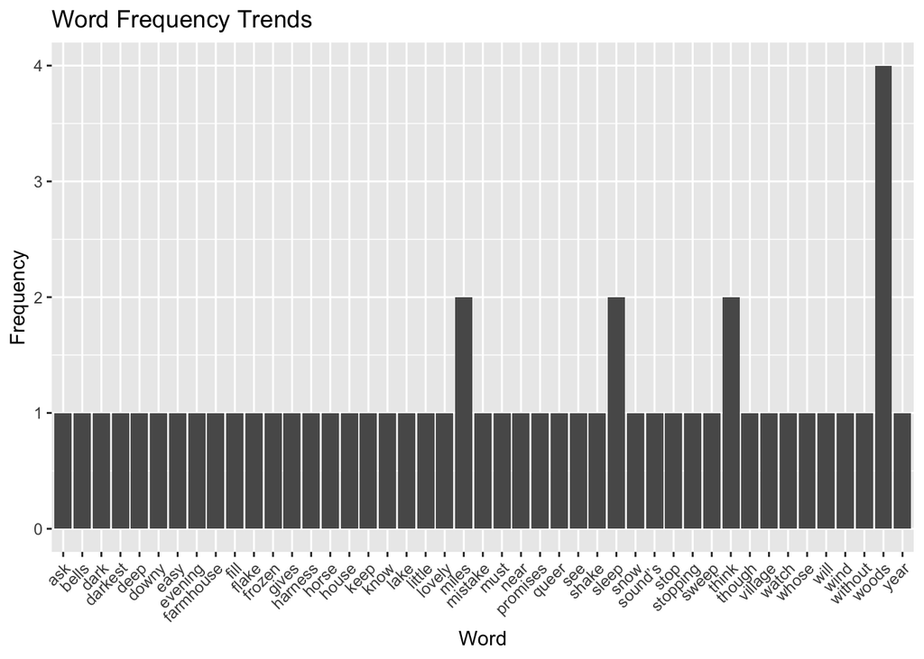

```r
ggplot(d, aes(x = word, y = freq)) +
  geom_bar(stat = "identity") +
  labs(title = "Word Frequency Trends",
       x = "Word",
       y = "Frequency") +
   theme(axis.text.x = element_text(angle = 45, hjust = 1))
```

4

Go to and study the textmining R file again, Using the code provided, change the text link and produce your own word cloud. Screen shot your word cloud and post the image on Canvas. I used the link for the “I have a Dream Speech”, Find your own text source to use as data for your word cloud.

I used The Hill We Climb by Amanda Gorman. https://thehill.com/homenews/news/535052-read-transcript-of-amanda-gormans-inaugural-poem/

```r
library("tm")
library("SnowballC")
library("wordcloud")
library("RColorBrewer")
```

```r
file_path <- "TheHillWeClimb.txt"
text <- readLines(file_path)
docs <- Corpus(VectorSource(text))
inspect(docs)
```

```
## <<SimpleCorpus>>
## Metadata:  corpus specific: 1, document level (indexed): 0
## Content:  documents: 9
##
## [1] When day comes we ask ourselves, where can we find light in this never- ending shade? The loss we carry, a sea we must wade. We’ve braved the belly of the beast, we’ve learned that quiet isn’t always peace and the norms and notions of what just is, isn’t always justice. And yet the dawn is ou…
## [2] We, the successors of a country and a time where a skinny black girl descended from slaves and raised by a single mother can dream of becoming president only to find herself reciting for one. And, yes, we are far from polished, far from pristine, but that doesn’t mean we are striving to form …
## [3] So we lift our gazes not to what stands between us, but what stands before us. We close the divide because we know to put our future first, we must first put our differences aside. We lay down our arms so we can reach out our arms to one another, we seek harm to none and harmony for all.
## [4] Let the globe, if nothing else, say this is true: that even as we grieved, we grew, even as we hurt, we hoped, that even as we tired, we tried, that we’ll forever be tied together victorious, not because we will never again know defeat but because we will never again sow division.
## [5] Scripture tells us to envision that everyone shall sit under their own vine and fig tree and no one should make them afraid. If we’re to live up to our own time, then victory won’t lie in the blade, but in in all of the bridges we’ve made.
## [6] That is the promise to glade, the hill we climb if only we dare it because being American is more than a pride we inherit, it’s the past we step into and how we repair it. We’ve seen a force that would shatter our nation rather than share it. That would destroy our country if it meant delayin…
## [7] In this truth, in this faith, we trust, for while we have our eyes on the future, history has its eyes on us, this is the era of just redemption we feared in its inception we did not feel prepared to be the heirs of such a terrifying hour but within it we found the power to author a new chapt…
## [8] We will not march back to what was but move to what shall be, a country that is bruised but whole, benevolent but bold, fierce and free, we will not be turned around or interrupted by intimidation because we know our inaction and inertia will be the inheritance of the next generation, our blu…
## [9] So let us leave behind a country better than the one we were left, with every breath from my bronze, pounded chest, we will raise this wounded world into a wondrous one, we will rise from the golden hills of the West, we will rise from the windswept Northeast where our forefathers first reali…
```

```r
toSpace <- content_transformer(function (x , pattern ) gsub(pattern, " ", x))
docs <- tm_map(docs, toSpace, "/")
docs <- tm_map(docs, toSpace, "@")
docs <- tm_map(docs, toSpace, "\\|")
```

```r
# Convert the text to lower case
docs <- tm_map(docs, content_transformer(tolower))
# Remove numbers
docs <- tm_map(docs, removeNumbers)
# Remove your own stop word
# specify your stopwords as a character vector
docs <- tm_map(docs, removeWords, c("we’ve", "isn’t", "we’ll", "we’re", "won’t", "doesn’t", "it’s"))
# Remove english common stopwords
docs <- tm_map(docs, removeWords, stopwords("english"))
# Remove punctuations
docs <- tm_map(docs, removePunctuation)
# Eliminate extra white spaces
docs <- tm_map(docs, stripWhitespace)
```

```r
dtm <- TermDocumentMatrix(docs)
m <- as.matrix(dtm)
v <- sort(rowSums(m),decreasing=TRUE)
d <- data.frame(word = names(v),freq=v)
head(d, 10)
```

```
##            word freq
## will       will   12
## can         can    6
## country country    6
## one         one    6
## never     never    4
## rise       rise    4
## always   always    3
## nation   nation    3
## first     first    3
## know       know    3
```

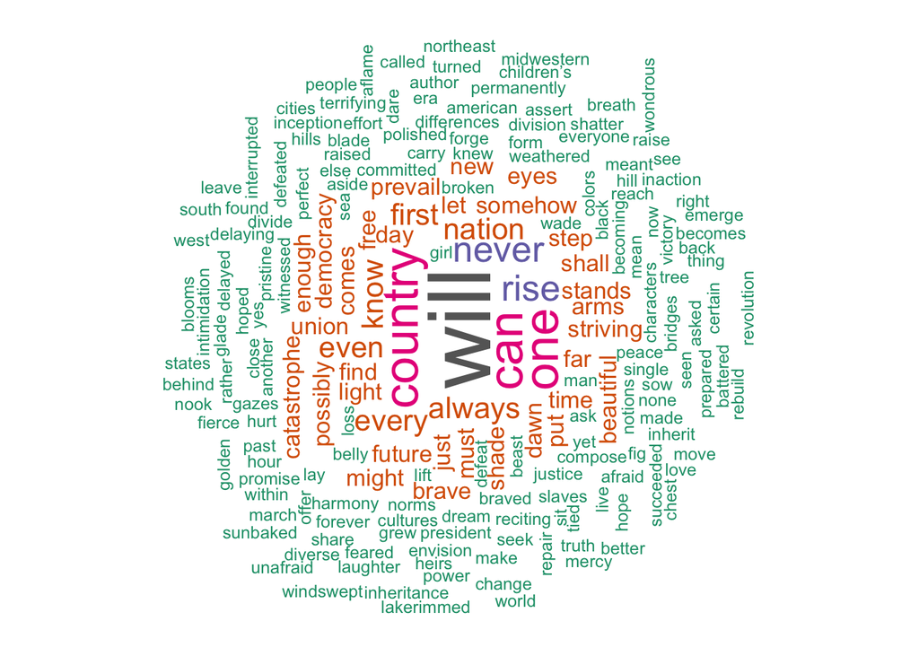

```r
set.seed(1234)
wordcloud(words = d$word, freq = d$freq, min.freq = 1,
          max.words=200, random.order=FALSE, rot.per=0.35,
          colors=brewer.pal(8, "Dark2"))
```

5

Use and show an R coding structure (found in your notes) that will produce the following matrix

```r
a <- matrix(nrow = 5, ncol = 5)
for (b in 1:5) {
  for (c in 1:5) {
    a[b, c] <- (b + c)^3
  }
}
print(a)
```

```
##      [,1] [,2] [,3] [,4] [,5]
## [1,]    8   27   64  125  216
## [2,]   27   64  125  216  343
## [3,]   64  125  216  343  512
## [4,]  125  216  343  512  729
## [5,]  216  343  512  729 1000
```